# Assignment 5: Exercise in Data Visualization.

Oscar Feng-Hsun Chang

In this assignment, I used baseball statistic data downloaded from [FanGraphs website](http://www.fangraphs.com) simply because I’m interested in baseball. This data include the following statistics of all the starting pitchers in the past 30 seasons (1986-2016).

- W: game winned
- L: game lost
- G: game played
- GS: game played as the starter
- IP: inning played in the whole season
- K9: strike out produced per 9 innings
- BB9: Balls produced per 9 innings
- BABIP: how many of a batter’s balls in play go for hits, excluding home runs
- LOB: Left on Base percentage, the percentage of base runners that a pitcher strands on base over the course of a season
- HRFB: Home Run to Fly Ball rate, ratio of how many home runs are hit against a pitcher for every fly ball they allow
- FIP: Fielding Independent Pitching, what a player’s ERA would look like over a given period of time if the pitcher were to have experienced league average results on balls in play and league average timing
- WAR: Wins Above Replacement, an attempt by the sabermetric baseball community to summarize a player’s total contributions to their team in one statistic
- WHIP: Walks plus Hits per Innings Pitched, measures how many base runners a pitcher lets up
- ERA: Earned Run Average, calculated by dividing a pitcher’s total number of Earned Runs allowed by his total number of Innings Pitched and multiply by nine
- Age: the pitcher’s age at the season

### Loading packages and data

First, I loaded the packages that are needed in my further analyses. Note that I use dplyr (I think dplyr is a special version of plyr that is designed specifically for data frame) and tidyr instead of plyr and reshape2. However, in order to demonstrate that I can manage reshape2 package, I duplicate some of my code in two packages.

```r
library(ggplot2)
library(dplyr)
library(tidyr)
library(plyr)
library(reshape2)
```

Now, load the data and skim the data type and data structure.

```r
setwd("D:/Courses/UM/2016_WN/EEB480_modelinfer/20160926")
AL_SP = read.csv(file="MLB_AL_SP_1986_2016.csv", header = TRUE, sep=",", fill=TRUE)
str(AL_SP)
```

```
## 'data.frame':    4600 obs. of  19 variables:
##  $ Season: int  1986 1986 1987 1988 1989 1998 1999 1999 1999 1999 ...
##  $ Name  : Factor w/ 1414 levels "A.J. Burnett",..: 1272 442 205 1271 749 620 26 997 1296 925 ...
##  $ Team  : Factor w/ 17 levels "Angels","Astros",..: 8 8 12 13 4 13 1 17 16 10 ...
##  $ W     : int  0 1 0 1 0 0 0 0 0 0 ...
##  $ L     : int  0 0 0 0 0 0 0 0 0 0 ...
##  $ G     : int  1 1 1 1 1 1 1 1 1 1 ...
##  $ GS    : int  1 1 1 1 1 1 1 1 1 1 ...
##  $ IP    : num  3 5 7 6 3 6 4 4 6 6 ...
##  $ K9    : num  6 5.4 14.1 6 18 ...
##  $ BB9   : num  0 1.8 0 3 0 1.5 0 2.25 3 0 ...
##  $ HR9   : num  0 0 0 0 0 0 0 0 0 0 ...
##  $ BABIP : num  0.25 0.214 0.231 0.3 0 0.267 0.231 0.2 0.222 0.286 ...
##  $ LOB   : num  1 1 1 1 1 1 1 1 1 1 ...
##  $ HRFB  : num  NA NA NA NA NA NA NA NA NA NA ...
##  $ FIP   : num  2.44 2.17 -0.27 2.44 -1.24 1.64 2.13 2.38 3.47 -0.87 ...
##  $ WAR   : num  0.1 0.2 0.6 0.2 0.2 0.3 0.2 0.2 0.2 0.5 ...
##  $ WHIP  : num  0.67 0.8 0.43 1.33 0 0.83 0.75 0.75 1 0.33 ...
##  $ ERA   : num  0 0 0 0 0 0 0 0 0 0 ...
##  $ Age   : int  29 23 25 31 25 23 31 32 28 24 ...
```

```r
head(AL_SP)
```

```
##   Season             Name      Team W L G GS IP    K9 BB9 HR9 BABIP LOB
## 1   1986   Steve Fireovid  Mariners 0 0 1  1  3  6.00 0.0   0 0.250   1
## 2   1986      Edwin Nunez  Mariners 1 0 1  1  5  5.40 1.8   0 0.214   1
## 3   1987 Calvin Schiraldi   Red Sox 0 0 1  1  7 14.14 0.0   0 0.231   1
## 4   1988       Steve Farr    Royals 1 0 1  1  6  6.00 3.0   0 0.300   1
## 5   1989       Jose Nunez Blue Jays 0 0 1  1  3 18.00 0.0   0 0.000   1
## 6   1998      Jeff Suppan    Royals 0 0 1  1  6  9.00 1.5   0 0.267   1
##   HRFB   FIP WAR WHIP ERA Age
## 1   NA  2.44 0.1 0.67   0  29
## 2   NA  2.17 0.2 0.80   0  23
## 3   NA -0.27 0.6 0.43   0  25
## 4   NA  2.44 0.2 1.33   0  31
## 5   NA -1.24 0.2 0.00   0  25
## 6   NA  1.64 0.3 0.83   0  23
```

Now use *arrange* function to sort the data first by Season(year) then by team and Pitcher’s name, so that it looks nicer.

```r
AL_SP = AL_SP %>% arrange(Season, Team, Name)
head(AL_SP)
```

```
##   Season            Name   Team  W  L  G GS    IP   K9  BB9  HR9 BABIP
## 1   1986      Don Sutton Angels 15 11 34 34 207.0 5.04 2.13 1.35 0.246
## 2   1986      Jim Slaton Angels  3  6 12 12  64.0 3.66 3.94 1.27 0.299
## 3   1986 John Candelaria Angels 10  2 16 16  91.2 7.95 2.55 0.39 0.255
## 4   1986  Kirk McCaskill Angels 17 10 33 33 244.1 7.40 3.39 0.70 0.271
## 5   1986       Mike Cook Angels  0  1  1  1   3.0 3.00 6.00 0.00 0.417
## 6   1986       Mike Witt Angels 18 10 34 34 269.0 6.96 2.44 0.74 0.256
##     LOB HRFB  FIP WAR WHIP   ERA Age
## 1 0.753   NA 4.35 2.2 1.16  3.74  41
## 2 0.600   NA 5.19 0.1 1.63  6.33  36
## 3 0.733   NA 2.52 3.0 1.03  2.55  32
## 4 0.738   NA 3.33 5.5 1.22  3.39  25
## 5 0.286   NA 4.10 0.0 2.33 12.00  22
## 6 0.756   NA 3.14 6.7 1.08  2.84  25
```

### Answering couple easy questions

```r
ALSP.all = AL_SP %>%
           filter(IP>1 & GS>1)
ALSP.all2 = AL_SP %>%
           subset(IP>1 & GS>1)

allSP = length(unique(ALSP.all$Name))
allSP
```

```
## [1] 1276
```

2.What are the average and standard deviation of each statistics of each year? To answer this question, I first have to reshape the data into a “long” form, so I use *gather* in *tidyr* package and *melt* in *reshape2* package.

```r
ALSP.all.long = ALSP.all %>%
                gather(key=stats, value=val, W, L, G, GS, IP, K9, BB9, HR9, BABIP, LOB, HRFB, FIP, WAR, WHIP, ERA, Age)
ALSP.all.long2 = ALSP.all %>%
                 melt(id.vars=colnames(ALSP.all)[1:3], variable.name="stats", value.name="val")

ALSP.all.long2$stats=as.character(ALSP.all.long2$stats)
# Beacuse melt function makes the variables (names as stats here) into factor, so I'll have to transform it
# into character for comparing the two dataframe.
all_equal(target=ALSP.all.long, current=ALSP.all.long2)
```

```
## [1] TRUE
```

Just for fun, I can *cast* (in *reshape2*) or *spread* (in *tidyr*) the long data frame back to wide form and it should be identical to the “ALSP.all”

```r
ALSP.all.wide = ALSP.all.long %>%
                spread(key=stats, value=val)

ALSP.all.wide2 = ALSP.all.long2 %>%
                 dcast(Season+Team+Name~stats, value.var=c("val"))

all_equal(target=ALSP.all.wide, current=ALSP.all.wide2)
```

```
## [1] TRUE
```

```r
all_equal(target=ALSP.all.wide, current=ALSP.all, convert=TRUE)
```

```
## [1] TRUE
```

```r
all_equal(target=ALSP.all.wide2, current=ALSP.all, convert=TRUE)
```

```
## [1] TRUE
```

With the long form dataframe, I can use *ddply* function to calculate the mean and standard deviation for each statistics. But it will be very long, so I just show the first 6 rows of this summary dataframe.

```r
SeasonSum = ddply(ALSP.all.long, ~stats+Season, summarize, mean=mean(val), sd=sd(val))
head(SeasonSum)
```

```
##   stats Season     mean       sd
## 1   Age   1986 27.86992 5.296085
## 2   Age   1987 28.33333 5.601173
## 3   Age   1988 27.67969 4.600468
## 4   Age   1989 27.86429 4.563242
## 5   Age   1990 27.47917 4.244237
## 6   Age   1991 27.42857 4.278342
```

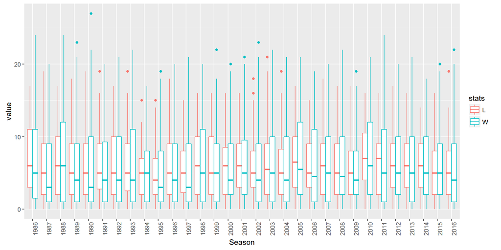

```r
ggplot(data=ALSP.all.long[which(ALSP.all.long$stats=="W"|ALSP.all.long$stats=="L"),],
       aes(x=factor(Season), y=val, color=stats),
       group=stats)+
  geom_boxplot(position="dodge")+ #self note, postition argument by default is "dodge"
  theme(axis.text.x=element_text(angle = 90, hjust=1))+
  xlab("Season")+
  ylab("value")
```

Interestingly, on average, a pitcher tend to loss more than win a game.

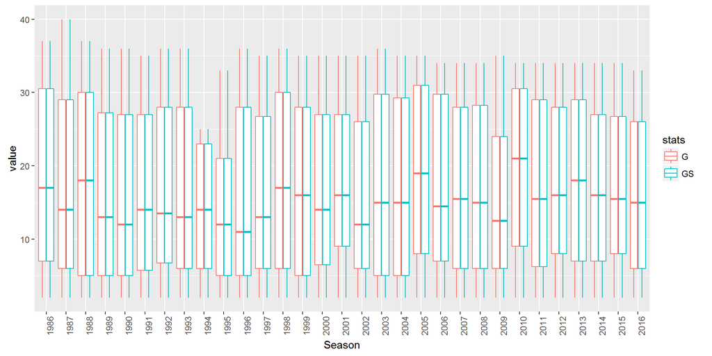

```r
ggplot(data=ALSP.all.long[which(ALSP.all.long$stats=="G"|ALSP.all.long$stats=="GS"),],
       aes(x=factor(Season), y=val, color=stats),
       group=stats)+
  geom_boxplot(position=position_dodge(width=0.8))+ #self note, or I can set how much each bar should dodge manually
  theme(axis.text.x=element_text(angle = 90, hjust=1))+
  xlab("Season")+
  ylab("value")
```

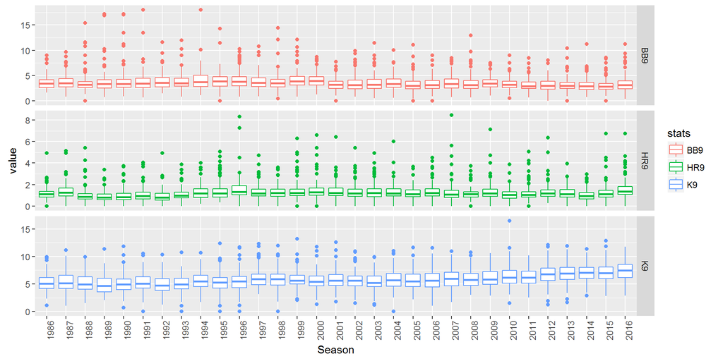

```r
ggplot(data=ALSP.all.long[which(ALSP.all.long$stats=="K9"|ALSP.all.long$stats=="BB9"|ALSP.all.long$stats=="HR9"),],
       aes(x=factor(Season), y=val, color=stats),
       group=stats)+
  geom_boxplot(position="dodge")+
  facet_grid(stats~., scales="free")+
  theme(axis.text.x=element_text(angle = 90, hjust=1))+
  xlab("Season")+
  ylab("value")
```